# Practical Machine Learning Project Assignment

Rawender Guron

1 July 2016

```r
library(knitr)
opts_chunk$set(echo = TRUE, message = FALSE, results = "markup", error = TRUE, warning = FALSE)
```

```r
library(ggplot2);library(GGally);library(markdown); library(stats)
library(lattice);library(plyr);library(caret);library(randomForest)
library(grid); library(graphics);library(gridExtra);library(reshape2)
library(doParallel); library(gbm)
```

### Executive Summary

The HAR (Human Activity Research) dataset contains data recorded by electronic accelerometer sensors worn to belt, arm, dumbbell and forearm of 6 participants while they performed a specific physical activity in 5 specific ways (classe variable). The objective of this practical model building exercise is to construct a predictive model that can correctly classify the activity based on the sensor data predictors. **The final result is a model using random forest algorithm that can classify with out of sample accuracy of more than 99%.**

### Getting and Cleaning the Dataset

The data has been generously made available for the study by http://groupware.les.inf.puc-rio.br/har. The data is in two sets - training https://d396qusza40orc.cloudfront.net/predmachlearn/pml-training.csv and testing https://d396qusza40orc.cloudfront.net/predmachlearn/pml-testing.csv. The training dataset has 160 variables. The 52 of the variables are going to be used as predictors in the model and the response variable is ‘classe’. The predictors are listed here.

```r
pml.training <- read.csv("~/MyRwork/Practical Machine Learning/pml-training.csv", stringsAsFactors=FALSE)
pml.testing <- read.csv("~/MyRwork/Practical Machine Learning/pml-testing.csv", stringsAsFactors=FALSE)
ml = pml.training[,-1]
ml = ml[,- grep('(kurtosis|skewness|max|min|amplitude|var|avg|stddev|user|cvtd|new|num|raw)_',names(ml))]
ml[,"classe"] = factor(ml[,"classe"])
names(ml[,-53])
```

```
##  [1] "roll_belt"            "pitch_belt"           "yaw_belt"
##  [4] "total_accel_belt"     "gyros_belt_x"         "gyros_belt_y"
##  [7] "gyros_belt_z"         "accel_belt_x"         "accel_belt_y"
## [10] "accel_belt_z"         "magnet_belt_x"        "magnet_belt_y"
## [13] "magnet_belt_z"        "roll_arm"             "pitch_arm"
## [16] "yaw_arm"              "total_accel_arm"      "gyros_arm_x"
## [19] "gyros_arm_y"          "gyros_arm_z"          "accel_arm_x"
## [22] "accel_arm_y"          "accel_arm_z"          "magnet_arm_x"
## [25] "magnet_arm_y"         "magnet_arm_z"         "roll_dumbbell"
## [28] "pitch_dumbbell"       "yaw_dumbbell"         "total_accel_dumbbell"
## [31] "gyros_dumbbell_x"     "gyros_dumbbell_y"     "gyros_dumbbell_z"
## [34] "accel_dumbbell_x"     "accel_dumbbell_y"     "accel_dumbbell_z"
## [37] "magnet_dumbbell_x"    "magnet_dumbbell_y"    "magnet_dumbbell_z"
## [40] "roll_forearm"         "pitch_forearm"        "yaw_forearm"
## [43] "total_accel_forearm"  "gyros_forearm_x"      "gyros_forearm_y"
## [46] "gyros_forearm_z"      "accel_forearm_x"      "accel_forearm_y"
## [49] "accel_forearm_z"      "magnet_forearm_x"     "magnet_forearm_y"
## [52] "magnet_forearm_z"
```

### Exploratory Analysis

A check of near zero variance and violin ggplot of all the predictors against ‘classe’, the response follows.

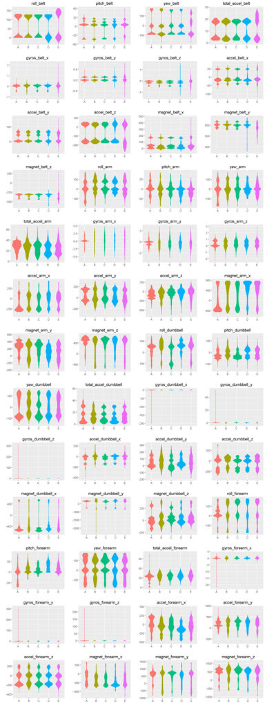

```r
nzv <- nearZeroVar(ml,saveMetrics = T)
if(any(nzv$nzv) | any(nzv$zeroVar)) nzv[nzv$nzv | nzv$zeroVar,] else message("No nearZeroVar variables found")
g = lapply(names(ml[-53]), function(i)
  ggplot(data=ml,aes_string(x="classe",y=i,colour="classe",fill="classe"))
  + geom_violin() + labs(x="",y="") + theme(legend.position="none")
  + ggtitle(i))
grid.arrange(grobs=g,ncol=4,nrow=13)
```

### Imputation of Outliers

The exploratory analysis reveals some outliers that should be fixed by imputation.

```r
ml[16025,"accel_belt_x"] = NA
ml[5373,"total_accel_dumbbell"] = NA
ml[5373,"gyros_dumbbell_x"] = NA
ml[5373,"gyros_dumbbell_y"] = NA
ml[5373,"gyros_dumbbell_z"] = NA
ml[5373,"accel_dumbbell_x"] = NA
ml[5373,"total_accel_forearm"] = NA
ml[5373,"gyros_forearm_x"] = NA
ml[5373,"gyros_forearm_y"] = NA
ml[5373,"gyros_forearm_z"] = NA
ml[5373,"accel_forearm_y"] = NA
ml[9274,"magnet_dumbbell_y"] = NA
ml[7265,"accel_forearm_x"] = NA
preObj = preProcess(ml,method = "knnImpute")
ml = predict(preObj,ml)
```

### Training the Model

We begin with splitting the training set further to train and evaluate the model. Then we apply random forest to build the model. Thereafter, the model is evaluated against the testing set (internal).

```r
set.seed(1257)
inTrain = createDataPartition(ml$classe, p = 0.60, list = F)
inTrain[inTrain %in% c(5373,7265,9274,16025)]
```

```
## [1]  5373  7265  9274 16025
```

```r
ml.train = ml[inTrain,]
ml.test = ml[-inTrain,]
cl <- makeCluster(detectCores())
registerDoParallel(cl)

system.time(fitRF <- train(classe ~ ., data = ml.train, method = "rf"))
```

```
##    user  system elapsed
##   56.65    0.56 1849.75
```

```r
fitRF
```

```
## Random Forest
##
## 11776 samples
##    52 predictor
##     5 classes: 'A', 'B', 'C', 'D', 'E'
##
## No pre-processing
## Resampling: Bootstrapped (25 reps)
## Summary of sample sizes: 11776, 11776, 11776, 11776, 11776, 11776, ...
## Resampling results across tuning parameters:
##
##   mtry  Accuracy   Kappa
##    2    0.9851313  0.9811862
##   27    0.9856564  0.9818509
##   52    0.9770472  0.9709548
##
## Accuracy was used to select the optimal model using  the largest value.
## The final value used for the model was mtry = 27.
```

```r
confusionMatrix(fitRF)
```

```
## Bootstrapped (25 reps) Confusion Matrix
##
## (entries are percentual average cell counts across resamples)
##
##           Reference
## Prediction    A    B    C    D    E
##          A 28.4  0.3  0.0  0.0  0.0
##          B  0.1 18.8  0.2  0.0  0.0
##          C  0.0  0.1 17.2  0.4  0.0
##          D  0.0  0.0  0.1 16.0  0.1
##          E  0.0  0.0  0.0  0.0 18.2
##
##  Accuracy (average) : 0.9857
```

### Test the Model

```r
predRF = predict(fitRF,ml.test)
confusionMatrix(predRF,ml.test$classe)
```

```
## Confusion Matrix and Statistics
##
##           Reference
## Prediction    A    B    C    D    E
##          A 2231   18    0    0    0
##          B    1 1497    4    5    1
##          C    0    3 1353   13    3
##          D    0    0   11 1267    2
##          E    0    0    0    1 1436
##
## Overall Statistics
##
##                Accuracy : 0.9921
##                  95% CI : (0.9899, 0.9939)
##     No Information Rate : 0.2845
##     P-Value [Acc > NIR] : < 2.2e-16
##
##                   Kappa : 0.99
##  Mcnemar's Test P-Value : NA
##
## Statistics by Class:
##
##                      Class: A Class: B Class: C Class: D Class: E
## Sensitivity            0.9996   0.9862   0.9890   0.9852   0.9958
## Specificity            0.9968   0.9983   0.9971   0.9980   0.9998
## Pos Pred Value         0.9920   0.9927   0.9862   0.9898   0.9993
## Neg Pred Value         0.9998   0.9967   0.9977   0.9971   0.9991
## Prevalence             0.2845   0.1935   0.1744   0.1639   0.1838
## Detection Rate         0.2843   0.1908   0.1724   0.1615   0.1830
## Detection Prevalence   0.2866   0.1922   0.1749   0.1631   0.1832
## Balanced Accuracy      0.9982   0.9922   0.9931   0.9916   0.9978
```

The model has test error of under 1%. We can reasonably expect out of sample error to be close to, or under, 1%.

### Prediction on Coursera Testing set

```r
pml.testing = pml.testing[,-1]
pml.testing = pml.testing[,- grep('(kurtosis|skewness|max|min|amplitude|var|avg|stddev|user|cvtd|new|num|raw)_',names(pml.testing))]
pml.testing[,"problem_id"] = factor(pml.testing[,"problem_id"])
pml.testing = predict(preObj, pml.testing)
predTest = predict(fitRF, pml.testing)
testResult <- data.frame(problem_id = pml.testing$problem_id, classe = predTest)
write.csv(testResult, file = "pml_test_answers.csv", row.names=FALSE)
```

The R markdown file, the HTML file, and the CSV answers file are going to be available on github.